# Models2_6

En el cuaderno anterior, se creó una arquitectura de redes neuronales con 1 capa convolucional y 2 densas. Se observó que ese primer modelo obtuvo un accuracy en el subconjunto de validación de 0.74, lo cual si bien no es tan bueno como se quisiera, es un buen comienzo. Por lo mismo, en este cuaderno se realizarán los 5 modelos adicionales con diferentes modificaciones para analizar si su desempeño aumenta o disminuye.

Para este segundo modelo, se buscará responer a la pregunta *"¿Cambiar al optimizador *SGD* y aumentar el número de épocas mejorará el desempeño del modelo en el subconjunto de Validación?*

```python
gpu_info = !nvidia-smi
gpu_info = '\n'.join(gpu_info)
if gpu_info.find('failed') >= 0:
  print('Not connected to a GPU')
else:
  print(gpu_info)
```

```
Mon Nov 17 17:18:48 2025
+-----------------------------------------------------------------------------------------+
| NVIDIA-SMI 550.54.15              Driver Version: 550.54.15      CUDA Version: 12.4     |
|-----------------------------------------+------------------------+----------------------+
| GPU  Name                 Persistence-M | Bus-Id          Disp.A | Volatile Uncorr. ECC |
| Fan  Temp   Perf          Pwr:Usage/Cap |           Memory-Usage | GPU-Util  Compute M. |
|                                         |                        |               MIG M. |
|=========================================+========================+======================|
|   0  NVIDIA L4                      Off |   00000000:00:03.0 Off |                    0 |
| N/A   36C    P8             11W /   72W |       0MiB /  23034MiB |      0%      Default |
|                                         |                        |                  N/A |
+-----------------------------------------+------------------------+----------------------+

+-----------------------------------------------------------------------------------------+
| Processes:                                                                              |
|  GPU   GI   CI        PID   Type   Process name                              GPU Memory |
|        ID   ID                                                               Usage      |
|=========================================================================================|
|  No running processes found                                                             |
+-----------------------------------------------------------------------------------------+
```

```python
print(tf.config.list_physical_devices('GPU'))
```

```
[PhysicalDevice(name='/physical_device:GPU:0', device_type='GPU')]
```

Nuevamente, esta se confirma que se esté trabajando con GPU.

```python
import cv2 as cv
import numpy as np
import matplotlib.pyplot as plt
import pandas as pd
import tensorflow as tf

from tensorflow.keras.utils import plot_model
from tensorflow.keras import layers, models
from tensorflow.keras.utils import to_categorical
from google.colab import drive
drive.mount('/content/drive')

from tensorflow.keras.preprocessing.image import ImageDataGenerator
```

Se importan las liberías necesarias

```python
# =============== PARÁMETROS BÁSICOS ===============
img_height, img_width = 28, 28
batch_size = 32
epochs = 30

# RUTA
train_dir = "/content/drive/MyDrive/Proyecto Final IA/Train"
```

Aquí se encuentra la primer modificacíon, que es aumentar el número de épocas que el modelo se entrenará. Es de los parámetros que se quiere provar si, al aumentarse, produce un efecto positivo en el desempeño

```python
# =============== GENERADORES (TRAIN / VAL) ===============
datagen = ImageDataGenerator(
    rescale=1./255,       # normaliza a [0,1]
    validation_split=0.2  # 80% train, 20% validación
)

train_generator = datagen.flow_from_directory(
    train_dir,
    target_size=(img_height, img_width),
    color_mode='grayscale',     # imágenes en escala de grises (28x28x1)
    batch_size=batch_size,
    class_mode='categorical',   # one-hot para 10 clases
    subset='training',
    shuffle=True
)

val_generator = datagen.flow_from_directory(
    train_dir,
    target_size=(img_height, img_width),
    color_mode='grayscale',
    batch_size=batch_size,
    class_mode='categorical',
    subset='validation',
    shuffle=False
)

print("Clases detectadas:", train_generator.class_indices)
```

```
Found 5126 images belonging to 10 classes.
Found 1277 images belonging to 10 classes.
Clases detectadas: {'0': 0, '1': 1, '2': 2, '3': 3, '4': 4, '5': 5, '6': 6, '7': 7, '8': 8, '9': 9}
```

En este bloque de código nuevamente se crean los conjuntos de entrenamiento y validación con sus respectivos labels

```python
model2=models.Sequential()
model2.add(layers.Conv2D(32,(3,3),padding='same',activation='relu',input_shape=(28,28,1)))

model2.add(layers.MaxPooling2D((2,2)))

model2.add(layers.Flatten())
# Capa oculta 1
model2.add(layers.Dense(128, activation="relu"))

#Capa oculta 2
model2.add(layers.Dense(64,activation='relu'))

# Output Layer

model2.add(layers.Dense(10,activation='softmax'))
```

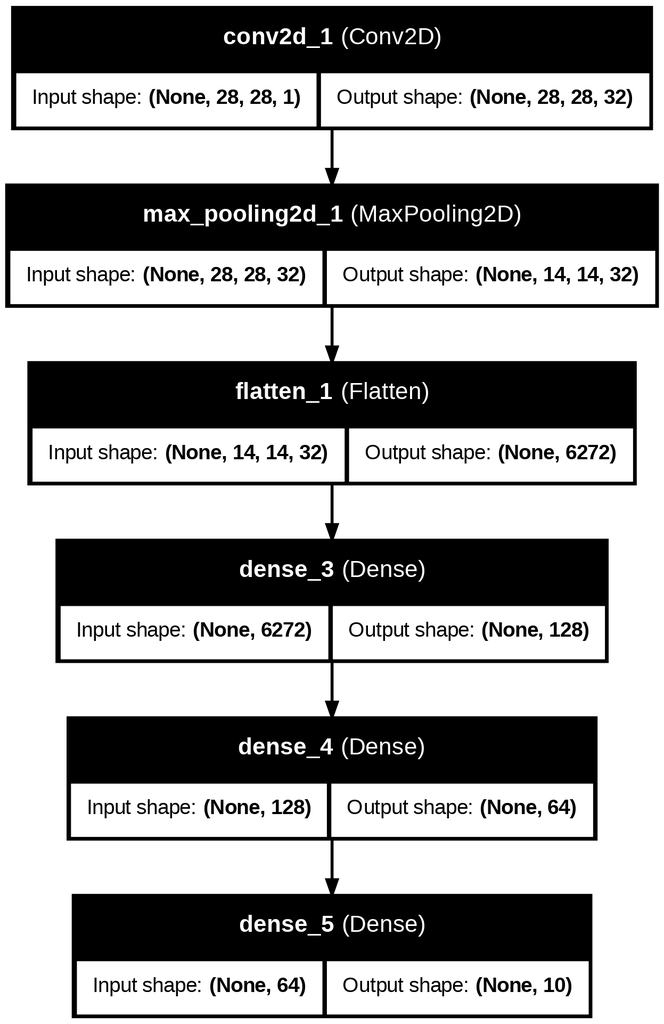

```python
from tensorflow.keras.utils import plot_model

# Guardar la imagen del modelo
plot_model(model2, to_file='model2_architecture.png', show_shapes=True, show_layer_names=True)

# Mostrar la imagen en el cuaderno
from IPython.display import Image
Image(filename='model2_architecture.png')
```

En este gráfico podemos ver la estructura del modelo. Observamos que no cambio con respecto al modelo inicial. Esto porque los cambios para este segundo modelo está en el optimizador utilizado, así como en el número de épocas en las que se entrena el modelo.

```python
#Optimizador
opt=tf.keras.optimizers.SGD(learning_rate=0.01, momentum=0.9)

# Funcion de paro
from tensorflow.keras.callbacks import EarlyStopping
early_stop=EarlyStopping(monitor='val_accuracy',patience=8,restore_best_weights=True)

model2.compile(optimizer=opt,loss='categorical_crossentropy',metrics=['accuracy'])

model2.summary()
```

```
Model: "sequential_1"
```

```
┏━━━━━━━━━━━━━━━━━━━━━━━━━━━━━━━━━┳━━━━━━━━━━━━━━━━━━━━━━━━┳━━━━━━━━━━━━━━━┓
┃ Layer (type)                    ┃ Output Shape           ┃       Param # ┃
┡━━━━━━━━━━━━━━━━━━━━━━━━━━━━━━━━━╇━━━━━━━━━━━━━━━━━━━━━━━━╇━━━━━━━━━━━━━━━┩
│ conv2d_1 (Conv2D)               │ (None, 28, 28, 32)     │           320 │
├─────────────────────────────────┼────────────────────────┼───────────────┤
│ max_pooling2d_1 (MaxPooling2D)  │ (None, 14, 14, 32)     │             0 │
├─────────────────────────────────┼────────────────────────┼───────────────┤
│ flatten_1 (Flatten)             │ (None, 6272)           │             0 │
├─────────────────────────────────┼────────────────────────┼───────────────┤
│ dense_3 (Dense)                 │ (None, 128)            │       802,944 │
├─────────────────────────────────┼────────────────────────┼───────────────┤
│ dense_4 (Dense)                 │ (None, 64)             │         8,256 │
├─────────────────────────────────┼────────────────────────┼───────────────┤
│ dense_5 (Dense)                 │ (None, 10)             │           650 │
└─────────────────────────────────┴────────────────────────┴───────────────┘
```

```
 Total params: 812,170 (3.10 MB)
```

```
 Trainable params: 812,170 (3.10 MB)
```

```
 Non-trainable params: 0 (0.00 B)
```

Aquí está la otra modificación al modelo. Se cambió el optimizador *Adam* a *SGD* con momentum. A diferencia del SGD estándar, que solo utiliza el gradiente actual, el SGD con momentum utiliza una media móvil exponencial de los gradientes anteriores para ajustar la actualización de los parámetros del modelo conforme se va entrenando. Se analizará si este optimizador mejora el desempeño del modelo.

```python
history = model2.fit(
    train_generator,
    epochs=epochs,
    validation_data=val_generator,callbacks=[early_stop]
)
```

```
161/161 ━━━━━━━━━━━━━━━━━━━━ 2361s 15s/step - accuracy: 0.1041 - loss: 2.3096 - val_accuracy: 0.1762 - val_loss: 2.2607
161/161 ━━━━━━━━━━━━━━━━━━━━ 47s 294ms/step - accuracy: 0.2967 - loss: 2.1340 - val_accuracy: 0.4683 - val_loss: 1.6252
161/161 ━━━━━━━━━━━━━━━━━━━━ 45s 280ms/step - accuracy: 0.5484 - loss: 1.4217 - val_accuracy: 0.6030 - val_loss: 1.2877
161/161 ━━━━━━━━━━━━━━━━━━━━ 45s 276ms/step - accuracy: 0.6638 - loss: 1.0383 - val_accuracy: 0.6735 - val_loss: 1.1217
161/161 ━━━━━━━━━━━━━━━━━━━━ 48s 299ms/step - accuracy: 0.7327 - loss: 0.8311 - val_accuracy: 0.7056 - val_loss: 1.0354
161/161 ━━━━━━━━━━━━━━━━━━━━ 44s 274ms/step - accuracy: 0.7860 - loss: 0.6600 - val_accuracy: 0.6954 - val_loss: 1.0282
161/161 ━━━━━━━━━━━━━━━━━━━━ 48s 297ms/step - accuracy: 0.8247 - loss: 0.5687 - val_accuracy: 0.7463 - val_loss: 0.9450
161/161 ━━━━━━━━━━━━━━━━━━━━ 47s 294ms/step - accuracy: 0.8554 - loss: 0.4862 - val_accuracy: 0.7259 - val_loss: 0.9799
161/161 ━━━━━━━━━━━━━━━━━━━━ 45s 282ms/step - accuracy: 0.8689 - loss: 0.4145 - val_accuracy: 0.7416 - val_loss: 0.9834
161/161 ━━━━━━━━━━━━━━━━━━━━ 48s 299ms/step - accuracy: 0.8916 - loss: 0.3457 - val_accuracy: 0.7588 - val_loss: 0.9860
161/161 ━━━━━━━━━━━━━━━━━━━━ 48s 300ms/step - accuracy: 0.9087 - loss: 0.2845 - val_accuracy: 0.7549 - val_loss: 1.0533
161/161 ━━━━━━━━━━━━━━━━━━━━ 44s 275ms/step - accuracy: 0.9260 - loss: 0.2361 - val_accuracy: 0.7463 - val_loss: 1.2497
161/161 ━━━━━━━━━━━━━━━━━━━━ 46s 285ms/step - accuracy: 0.9395 - loss: 0.1968 - val_accuracy: 0.7525 - val_loss: 1.1866
161/161 ━━━━━━━━━━━━━━━━━━━━ 48s 299ms/step - accuracy: 0.9580 - loss: 0.1497 - val_accuracy: 0.7502 - val_loss: 1.2355
161/161 ━━━━━━━━━━━━━━━━━━━━ 45s 278ms/step - accuracy: 0.9669 - loss: 0.1153 - val_accuracy: 0.7471 - val_loss: 1.3219
161/161 ━━━━━━━━━━━━━━━━━━━━ 45s 281ms/step - accuracy: 0.9625 - loss: 0.1206 - val_accuracy: 0.7541 - val_loss: 1.5567
161/161 ━━━━━━━━━━━━━━━━━━━━ 48s 296ms/step - accuracy: 0.9722 - loss: 0.0930 - val_accuracy: 0.7580 - val_loss: 1.4521
161/161 ━━━━━━━━━━━━━━━━━━━━ 49s 303ms/step - accuracy: 0.9852 - loss: 0.0641 - val_accuracy: 0.7604 - val_loss: 1.5733
161/161 ━━━━━━━━━━━━━━━━━━━━ 45s 280ms/step - accuracy: 0.9768 - loss: 0.0793 - val_accuracy: 0.7753 - val_loss: 1.5350
161/161 ━━━━━━━━━━━━━━━━━━━━ 48s 298ms/step - accuracy: 0.9779 - loss: 0.0773 - val_accuracy: 0.7549 - val_loss: 1.7086
161/161 ━━━━━━━━━━━━━━━━━━━━ 48s 301ms/step - accuracy: 0.9902 - loss: 0.0434 - val_accuracy: 0.7424 - val_loss: 1.8709
161/161 ━━━━━━━━━━━━━━━━━━━━ 48s 299ms/step - accuracy: 0.9776 - loss: 0.0775 - val_accuracy: 0.7580 - val_loss: 1.6814
161/161 ━━━━━━━━━━━━━━━━━━━━ 48s 300ms/step - accuracy: 0.9816 - loss: 0.0672 - val_accuracy: 0.7486 - val_loss: 1.7183
161/161 ━━━━━━━━━━━━━━━━━━━━ 48s 300ms/step - accuracy: 0.9697 - loss: 0.1130 - val_accuracy: 0.7627 - val_loss: 1.7139
161/161 ━━━━━━━━━━━━━━━━━━━━ 49s 302ms/step - accuracy: 0.9919 - loss: 0.0373 - val_accuracy: 0.7596 - val_loss: 1.9666
161/161 ━━━━━━━━━━━━━━━━━━━━ 48s 297ms/step - accuracy: 0.9810 - loss: 0.0682 - val_accuracy: 0.7565 - val_loss: 1.9299
161/161 ━━━━━━━━━━━━━━━━━━━━ 47s 292ms/step - accuracy: 0.9839 - loss: 0.0548 - val_accuracy: 0.7612 - val_loss: 1.9082
```

```python
val_loss, val_acc = model2.evaluate(val_generator)
print("Pérdida en validación:", val_loss)
print("Accuracy en validación:", val_acc)
```

```
40/40 ━━━━━━━━━━━━━━━━━━━━ 7s 169ms/step - accuracy: 0.7754 - loss: 1.7718
Pérdida en validación: 1.5349663496017456
Accuracy en validación: 0.775254487991333
```

```python
# Guardar el modelo

model2.save("model2.keras")
```

Para este tercer modelo, se hará la pregunta *"¿Agregar una capa convolucional a la arquitectura mejora al desempeño del modelo en el subconjunto de entrenamiento y validación?*

Se pretente intenrar reducir la diferencia entre el accuracy de train y de validation, que probablemente se debe a *overfitting* en el modelo.

```python
model3 = models.Sequential()
model3.add(layers.Conv2D(32, (3,3), padding='same', activation='relu',
                        input_shape=(28,28,1)))
model3.add(layers.MaxPooling2D((2,2)))

# Segunda capa convolucional
model3.add(layers.Conv2D(64, (3,3), padding='same', activation='relu'))
model3.add(layers.MaxPooling2D((2,2)))

model3.add(layers.Flatten())
model3.add(layers.Dense(128, activation="relu"))
model3.add(layers.Dense(64, activation='relu'))
model3.add(layers.Dense(10, activation='softmax'))
```

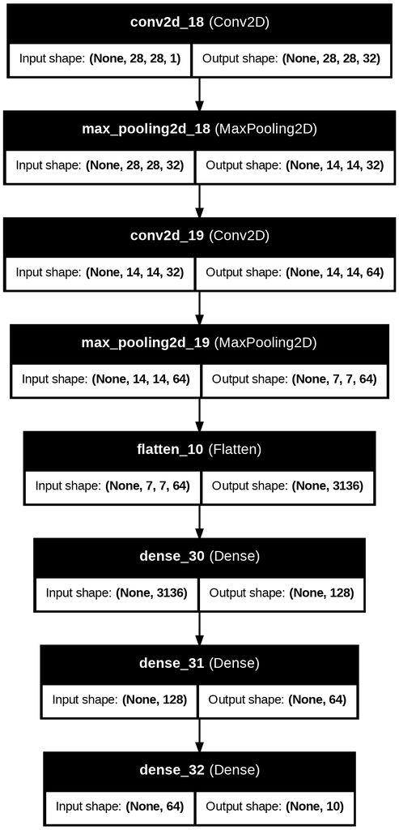

```python
# Guardar la imagen del modelo
plot_model(model3, to_file='model3_architecture.png', show_shapes=True, show_layer_names=True)

# Mostrar la imagen en el cuaderno
Image(filename='model3_architecture.png')
```

Este gráfico muestra la nueva arquitectura del modelo. La diferencia con el modelo base, es que se le agregó una capa convolucional con MaxPooling. Por lo mismo, el número de parámetros tendrá un decremento bastante considerable, como se observa en la sección del summary. Esto no es necesariamente malo, solo estamos haciendo el modelo un poco menos "complejo" en cuanto a la cantidad de parámetros.

```python
#Optimizador
opt=tf.keras.optimizers.SGD(learning_rate=0.01, momentum=0.9)

# Funcion de paro
from tensorflow.keras.callbacks import EarlyStopping
early_stop=EarlyStopping(monitor='val_accuracy',patience=8,restore_best_weights=True)

model3.compile(optimizer=opt,loss='categorical_crossentropy',metrics=['accuracy'])

model3.summary()
```

```
Model: "sequential_8"
```

```
┏━━━━━━━━━━━━━━━━━━━━━━━━━━━━━━━━━┳━━━━━━━━━━━━━━━━━━━━━━━━┳━━━━━━━━━━━━━━━┓
┃ Layer (type)                    ┃ Output Shape           ┃       Param # ┃
┡━━━━━━━━━━━━━━━━━━━━━━━━━━━━━━━━━╇━━━━━━━━━━━━━━━━━━━━━━━━╇━━━━━━━━━━━━━━━┩
│ conv2d_14 (Conv2D)              │ (None, 28, 28, 32)     │           320 │
├─────────────────────────────────┼────────────────────────┼───────────────┤
│ max_pooling2d_14 (MaxPooling2D) │ (None, 14, 14, 32)     │             0 │
├─────────────────────────────────┼────────────────────────┼───────────────┤
│ conv2d_15 (Conv2D)              │ (None, 14, 14, 64)     │        18,496 │
├─────────────────────────────────┼────────────────────────┼───────────────┤
│ max_pooling2d_15 (MaxPooling2D) │ (None, 7, 7, 64)       │             0 │
├─────────────────────────────────┼────────────────────────┼───────────────┤
│ flatten_8 (Flatten)             │ (None, 3136)           │             0 │
├─────────────────────────────────┼────────────────────────┼───────────────┤
│ dense_24 (Dense)                │ (None, 128)            │       401,536 │
├─────────────────────────────────┼────────────────────────┼───────────────┤
│ dense_25 (Dense)                │ (None, 64)             │         8,256 │
├─────────────────────────────────┼────────────────────────┼───────────────┤
│ dense_26 (Dense)                │ (None, 10)             │           650 │
└─────────────────────────────────┴────────────────────────┴───────────────┘
```

```
 Total params: 429,258 (1.64 MB)
```

```
 Trainable params: 429,258 (1.64 MB)
```

```
 Non-trainable params: 0 (0.00 B)
```

```python
history3 = model3.fit(train_generator, epochs=epochs, validation_data=val_generator,callbacks=[early_stop])
```

```
161/161 ━━━━━━━━━━━━━━━━━━━━ 46s 287ms/step - accuracy: 0.4272 - loss: 1.7051 - val_accuracy: 0.6288 - val_loss: 1.2408
161/161 ━━━━━━━━━━━━━━━━━━━━ 50s 311ms/step - accuracy: 0.6669 - loss: 1.0133 - val_accuracy: 0.7478 - val_loss: 0.9048
161/161 ━━━━━━━━━━━━━━━━━━━━ 50s 308ms/step - accuracy: 0.7543 - loss: 0.7579 - val_accuracy: 0.7103 - val_loss: 0.9112
161/161 ━━━━━━━━━━━━━━━━━━━━ 50s 313ms/step - accuracy: 0.8067 - loss: 0.6084 - val_accuracy: 0.7878 - val_loss: 0.7109
161/161 ━━━━━━━━━━━━━━━━━━━━ 47s 291ms/step - accuracy: 0.8435 - loss: 0.4779 - val_accuracy: 0.7901 - val_loss: 0.7105
161/161 ━━━━━━━━━━━━━━━━━━━━ 50s 312ms/step - accuracy: 0.8522 - loss: 0.4415 - val_accuracy: 0.7987 - val_loss: 0.6817
161/161 ━━━━━━━━━━━━━━━━━━━━ 51s 315ms/step - accuracy: 0.8800 - loss: 0.3603 - val_accuracy: 0.8066 - val_loss: 0.7005
161/161 ━━━━━━━━━━━━━━━━━━━━ 48s 295ms/step - accuracy: 0.9068 - loss: 0.3042 - val_accuracy: 0.8128 - val_loss: 0.7338
161/161 ━━━━━━━━━━━━━━━━━━━━ 51s 315ms/step - accuracy: 0.9067 - loss: 0.2617 - val_accuracy: 0.8027 - val_loss: 0.7740
161/161 ━━━━━━━━━━━━━━━━━━━━ 49s 306ms/step - accuracy: 0.9255 - loss: 0.2274 - val_accuracy: 0.8168 - val_loss: 0.7828
161/161 ━━━━━━━━━━━━━━━━━━━━ 47s 289ms/step - accuracy: 0.9454 - loss: 0.1635 - val_accuracy: 0.8191 - val_loss: 0.7857
161/161 ━━━━━━━━━━━━━━━━━━━━ 49s 302ms/step - accuracy: 0.9476 - loss: 0.1573 - val_accuracy: 0.8238 - val_loss: 0.8481
161/161 ━━━━━━━━━━━━━━━━━━━━ 50s 312ms/step - accuracy: 0.9406 - loss: 0.1723 - val_accuracy: 0.8379 - val_loss: 0.7203
161/161 ━━━━━━━━━━━━━━━━━━━━ 47s 294ms/step - accuracy: 0.9585 - loss: 0.1316 - val_accuracy: 0.8152 - val_loss: 0.9574
161/161 ━━━━━━━━━━━━━━━━━━━━ 51s 317ms/step - accuracy: 0.9714 - loss: 0.0867 - val_accuracy: 0.8356 - val_loss: 0.9147
161/161 ━━━━━━━━━━━━━━━━━━━━ 48s 300ms/step - accuracy: 0.9802 - loss: 0.0691 - val_accuracy: 0.8442 - val_loss: 0.9630
161/161 ━━━━━━━━━━━━━━━━━━━━ 51s 316ms/step - accuracy: 0.9824 - loss: 0.0540 - val_accuracy: 0.8473 - val_loss: 0.9826
161/161 ━━━━━━━━━━━━━━━━━━━━ 51s 316ms/step - accuracy: 0.9707 - loss: 0.0899 - val_accuracy: 0.8254 - val_loss: 1.0252
161/161 ━━━━━━━━━━━━━━━━━━━━ 51s 314ms/step - accuracy: 0.9762 - loss: 0.0810 - val_accuracy: 0.8442 - val_loss: 1.0397
161/161 ━━━━━━━━━━━━━━━━━━━━ 48s 298ms/step - accuracy: 0.9850 - loss: 0.0486 - val_accuracy: 0.8269 - val_loss: 1.0508
161/161 ━━━━━━━━━━━━━━━━━━━━ 50s 310ms/step - accuracy: 0.9793 - loss: 0.0627 - val_accuracy: 0.8340 - val_loss: 1.0447
161/161 ━━━━━━━━━━━━━━━━━━━━ 50s 312ms/step - accuracy: 0.9826 - loss: 0.0613 - val_accuracy: 0.8309 - val_loss: 1.0565
161/161 ━━━━━━━━━━━━━━━━━━━━ 49s 302ms/step - accuracy: 0.9913 - loss: 0.0288 - val_accuracy: 0.8379 - val_loss: 1.1596
161/161 ━━━━━━━━━━━━━━━━━━━━ 51s 314ms/step - accuracy: 0.9945 - loss: 0.0285 - val_accuracy: 0.8316 - val_loss: 1.0607
161/161 ━━━━━━━━━━━━━━━━━━━━ 48s 298ms/step - accuracy: 0.9936 - loss: 0.0293 - val_accuracy: 0.8442 - val_loss: 1.0558
```

```python
val_loss, val_acc = model3.evaluate(val_generator)
print("Pérdida en validación:", val_loss)
print("Accuracy en validación:", val_acc)
```

```
 1/40 ━━━━━━━━━━━━━━━━━━━━ 5s 133ms/step - accuracy: 0.7500 - loss: 1.2658
```

```
40/40 ━━━━━━━━━━━━━━━━━━━━ 7s 170ms/step - accuracy: 0.8458 - loss: 1.0310
Pérdida en validación: 0.9825817942619324
Accuracy en validación: 0.8472983837127686
```

```python
# Guardar el modelo

model3.save("model3.keras")
```

Después de haber entrenado el modelo, se obtuvo un accuracy en el test de 0.8472. Esto implica una mejora bastante considerable comparado al modelo anterior. Por lo mismo, es adecuado concluir que fue bastante beneficioso agregar una capa convolucional al modelo, pues incrementó el accuracy en validación. Sin embargo, vemos aún una deferencia muy marcada entre el train y el test, por lo que el problema de *overfitting* probablemente sigue presente, y se intentará mejorar.

Para este cuarto modelo, se hará la pregunta *¿Podemos reducir el overfitting sin perder mucha capacidad de representación?*. Para ello, se utilizarán regularización del tipo *Dropout* y *L2*.

```python
from tensorflow.keras import regularizers

model4 = models.Sequential()
model4.add(layers.Conv2D(32, (3,3), padding='same', activation='relu',
                        input_shape=(28,28,1)))
model4.add(layers.MaxPooling2D((2,2)))
model4.add(layers.Conv2D(64, (3,3), padding='same', activation='relu'))
model4.add(layers.MaxPooling2D((2,2)))

model4.add(layers.Flatten())
model4.add(layers.Dense(128, activation="relu",
                        kernel_regularizer=regularizers.l2(1e-4)))
model4.add(layers.Dropout(0.5))
model4.add(layers.Dense(64, activation='relu',
                        kernel_regularizer=regularizers.l2(1e-4)))
model4.add(layers.Dense(10, activation='softmax'))
```

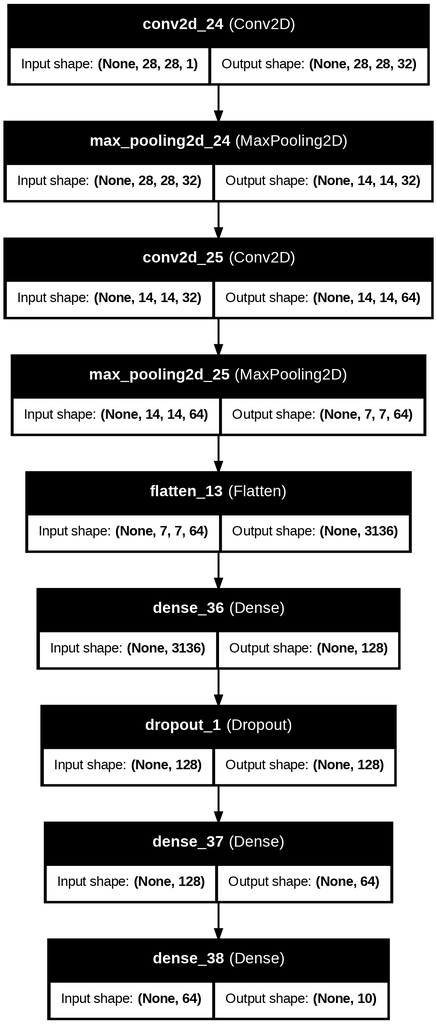

```python
# Guardar la imagen del modelo
plot_model(model4, to_file='model4_architecture.png', show_shapes=True, show_layer_names=True)

# Mostrar la imagen en el cuaderno
from IPython.display import Image
Image(filename='model4_architecture.png')
```

Aquí podemos visualizar la arquitectura de este nuevo modelo. La red mantiene la arquitectura con 2 conv + 2 maxpool, sin embargo incorpora *Dropout Regularization*. Esta función apaga neuronas en grupos aleatorios cada época del entrenamiento. El parámetro dentro de la función indica el porcentaje o fracción de todas las neuronas que se van a apagar. Para esta arquitectura, se decidió incluir una capa de Dropout con porcentaje de apagado del 50%, entre las capas densas con el objetivo de intentar reducir el *overfitting* que se ha estado observando en los modelos previos.

A este modelo también se le añade *L2 Regularization*. Esta es una técnica de que previene el sobreajuste añadiendo un término de penalización a la función de coste proporcional al cuadrado de los pesos del modelo, dado por la siguiente ecuación:

$$ J(\omega) = \sum_{i=0}^{N} C_i \;+\; \sum_{j=0}^{M} x_{ij}\,\omega_j^2 \;+\; \lambda \sum_{j=0}^{M} \omega_j^2 $$

Donde

- $J(\omega)$ es la función de costo
- $\omega_j$ es el *j-ésimo* peso del modelo
- $x_{ij}$ es el dato de entrada que se conecta al *j-ésimo* peso del modelo
- $\lambda \sum_{j=0}^{M} \omega_j^2$ es en si el término *L2* de regularización
- $\lambda$ es el hyperparámetro de regularizacion. Si es muy pequeño, penaliza poco, y penalizará más severamente cuando este parámetro incrementa.

Esta nueva función de costo fomenta pesos más pequeños y equilibrados, lo que da lugar a un modelo más simple y generalizado que funciona mejor con nuevos datos.

```python
#Optimizador
opt=tf.keras.optimizers.SGD(learning_rate=0.005, momentum=0.9)

# Funcion de paro
from tensorflow.keras.callbacks import EarlyStopping
early_stop=EarlyStopping(monitor='val_accuracy',patience=8,restore_best_weights=True)

model4.compile(optimizer=opt,loss='categorical_crossentropy',metrics=['accuracy'])

model4.summary()
```

```
Model: "sequential_13"
```

```
┏━━━━━━━━━━━━━━━━━━━━━━━━━━━━━━━━━┳━━━━━━━━━━━━━━━━━━━━━━━━┳━━━━━━━━━━━━━━━┓
┃ Layer (type)                    ┃ Output Shape           ┃       Param # ┃
┡━━━━━━━━━━━━━━━━━━━━━━━━━━━━━━━━━╇━━━━━━━━━━━━━━━━━━━━━━━━╇━━━━━━━━━━━━━━━┩
│ conv2d_24 (Conv2D)              │ (None, 28, 28, 32)     │           320 │
├─────────────────────────────────┼────────────────────────┼───────────────┤
│ max_pooling2d_24 (MaxPooling2D) │ (None, 14, 14, 32)     │             0 │
├─────────────────────────────────┼────────────────────────┼───────────────┤
│ conv2d_25 (Conv2D)              │ (None, 14, 14, 64)     │        18,496 │
├─────────────────────────────────┼────────────────────────┼───────────────┤
│ max_pooling2d_25 (MaxPooling2D) │ (None, 7, 7, 64)       │             0 │
├─────────────────────────────────┼────────────────────────┼───────────────┤
│ flatten_13 (Flatten)            │ (None, 3136)           │             0 │
├─────────────────────────────────┼────────────────────────┼───────────────┤
│ dense_36 (Dense)                │ (None, 128)            │       401,536 │
├─────────────────────────────────┼────────────────────────┼───────────────┤
│ dropout_1 (Dropout)             │ (None, 128)            │             0 │
├─────────────────────────────────┼────────────────────────┼───────────────┤
│ dense_37 (Dense)                │ (None, 64)             │         8,256 │
├─────────────────────────────────┼────────────────────────┼───────────────┤
│ dense_38 (Dense)                │ (None, 10)             │           650 │
└─────────────────────────────────┴────────────────────────┴───────────────┘
```

```
 Total params: 429,258 (1.64 MB)
```

```
 Trainable params: 429,258 (1.64 MB)
```

```
 Non-trainable params: 0 (0.00 B)
```

```python
history4 = model4.fit(train_generator, epochs=50, validation_data=val_generator,callbacks=[early_stop])
```

```
161/161 ━━━━━━━━━━━━━━━━━━━━ 51s 315ms/step - accuracy: 0.1033 - loss: 2.3378 - val_accuracy: 0.2091 - val_loss: 2.3108
161/161 ━━━━━━━━━━━━━━━━━━━━ 47s 292ms/step - accuracy: 0.1783 - loss: 2.2863 - val_accuracy: 0.3218 - val_loss: 2.0635
161/161 ━━━━━━━━━━━━━━━━━━━━ 51s 312ms/step - accuracy: 0.3619 - loss: 1.9152 - val_accuracy: 0.5435 - val_loss: 1.5511
161/161 ━━━━━━━━━━━━━━━━━━━━ 48s 297ms/step - accuracy: 0.5062 - loss: 1.5125 - val_accuracy: 0.6273 - val_loss: 1.2848
161/161 ━━━━━━━━━━━━━━━━━━━━ 51s 316ms/step - accuracy: 0.6025 - loss: 1.2215 - val_accuracy: 0.6954 - val_loss: 1.0938
161/161 ━━━━━━━━━━━━━━━━━━━━ 51s 316ms/step - accuracy: 0.6654 - loss: 1.0462 - val_accuracy: 0.7377 - val_loss: 0.9691
161/161 ━━━━━━━━━━━━━━━━━━━━ 50s 313ms/step - accuracy: 0.7012 - loss: 0.9534 - val_accuracy: 0.7525 - val_loss: 0.9281
161/161 ━━━━━━━━━━━━━━━━━━━━ 49s 302ms/step - accuracy: 0.7374 - loss: 0.8602 - val_accuracy: 0.7721 - val_loss: 0.8787
161/161 ━━━━━━━━━━━━━━━━━━━━ 48s 297ms/step - accuracy: 0.7469 - loss: 0.8009 - val_accuracy: 0.7917 - val_loss: 0.7978
161/161 ━━━━━━━━━━━━━━━━━━━━ 50s 314ms/step - accuracy: 0.7706 - loss: 0.7327 - val_accuracy: 0.7940 - val_loss: 0.8255
161/161 ━━━━━━━━━━━━━━━━━━━━ 49s 300ms/step - accuracy: 0.7783 - loss: 0.6972 - val_accuracy: 0.7823 - val_loss: 0.8097
161/161 ━━━━━━━━━━━━━━━━━━━━ 51s 316ms/step - accuracy: 0.7975 - loss: 0.6606 - val_accuracy: 0.8191 - val_loss: 0.7258
161/161 ━━━━━━━━━━━━━━━━━━━━ 50s 314ms/step - accuracy: 0.8138 - loss: 0.6084 - val_accuracy: 0.8238 - val_loss: 0.6997
161/161 ━━━━━━━━━━━━━━━━━━━━ 51s 320ms/step - accuracy: 0.8271 - loss: 0.5502 - val_accuracy: 0.8238 - val_loss: 0.7042
161/161 ━━━━━━━━━━━━━━━━━━━━ 47s 294ms/step - accuracy: 0.8228 - loss: 0.5583 - val_accuracy: 0.8152 - val_loss: 0.7163
161/161 ━━━━━━━━━━━━━━━━━━━━ 51s 313ms/step - accuracy: 0.8338 - loss: 0.5264 - val_accuracy: 0.8309 - val_loss: 0.6953
161/161 ━━━━━━━━━━━━━━━━━━━━ 50s 309ms/step - accuracy: 0.8518 - loss: 0.4969 - val_accuracy: 0.8316 - val_loss: 0.7152
161/161 ━━━━━━━━━━━━━━━━━━━━ 51s 315ms/step - accuracy: 0.8467 - loss: 0.5018 - val_accuracy: 0.8387 - val_loss: 0.7009
161/161 ━━━━━━━━━━━━━━━━━━━━ 49s 305ms/step - accuracy: 0.8555 - loss: 0.4712 - val_accuracy: 0.8309 - val_loss: 0.6812
161/161 ━━━━━━━━━━━━━━━━━━━━ 48s 301ms/step - accuracy: 0.8656 - loss: 0.4248 - val_accuracy: 0.8246 - val_loss: 0.7191
161/161 ━━━━━━━━━━━━━━━━━━━━ 51s 315ms/step - accuracy: 0.8756 - loss: 0.4174 - val_accuracy: 0.8348 - val_loss: 0.7076
161/161 ━━━━━━━━━━━━━━━━━━━━ 50s 312ms/step - accuracy: 0.8838 - loss: 0.3995 - val_accuracy: 0.8481 - val_loss: 0.6977
161/161 ━━━━━━━━━━━━━━━━━━━━ 50s 310ms/step - accuracy: 0.8927 - loss: 0.3547 - val_accuracy: 0.8332 - val_loss: 0.6954
161/161 ━━━━━━━━━━━━━━━━━━━━ 48s 301ms/step - accuracy: 0.8988 - loss: 0.3328 - val_accuracy: 0.8340 - val_loss: 0.7321
161/161 ━━━━━━━━━━━━━━━━━━━━ 49s 306ms/step - accuracy: 0.8946 - loss: 0.3512 - val_accuracy: 0.8418 - val_loss: 0.7240
161/161 ━━━━━━━━━━━━━━━━━━━━ 47s 294ms/step - accuracy: 0.9144 - loss: 0.3098 - val_accuracy: 0.8473 - val_loss: 0.7162
161/161 ━━━━━━━━━━━━━━━━━━━━ 48s 299ms/step - accuracy: 0.9134 - loss: 0.3113 - val_accuracy: 0.8434 - val_loss: 0.6903
161/161 ━━━━━━━━━━━━━━━━━━━━ 50s 308ms/step - accuracy: 0.9106 - loss: 0.3077 - val_accuracy: 0.8504 - val_loss: 0.7159
161/161 ━━━━━━━━━━━━━━━━━━━━ 51s 316ms/step - accuracy: 0.9177 - loss: 0.2825 - val_accuracy: 0.8403 - val_loss: 0.7109
161/161 ━━━━━━━━━━━━━━━━━━━━ 48s 300ms/step - accuracy: 0.9198 - loss: 0.3064 - val_accuracy: 0.8481 - val_loss: 0.7321
161/161 ━━━━━━━━━━━━━━━━━━━━ 50s 311ms/step - accuracy: 0.9207 - loss: 0.2773 - val_accuracy: 0.8418 - val_loss: 0.7816
161/161 ━━━━━━━━━━━━━━━━━━━━ 50s 313ms/step - accuracy: 0.9232 - loss: 0.2688 - val_accuracy: 0.8449 - val_loss: 0.7634
161/161 ━━━━━━━━━━━━━━━━━━━━ 48s 296ms/step - accuracy: 0.9358 - loss: 0.2396 - val_accuracy: 0.8465 - val_loss: 0.7764
161/161 ━━━━━━━━━━━━━━━━━━━━ 50s 310ms/step - accuracy: 0.9334 - loss: 0.2483 - val_accuracy: 0.8489 - val_loss: 0.7781
161/161 ━━━━━━━━━━━━━━━━━━━━ 49s 306ms/step - accuracy: 0.9315 - loss: 0.2308 - val_accuracy: 0.8473 - val_loss: 0.7822
161/161 ━━━━━━━━━━━━━━━━━━━━ 49s 304ms/step - accuracy: 0.9374 - loss: 0.2315 - val_accuracy: 0.8520 - val_loss: 0.7998
161/161 ━━━━━━━━━━━━━━━━━━━━ 50s 310ms/step - accuracy: 0.9433 - loss: 0.2221 - val_accuracy: 0.8418 - val_loss: 0.8359
161/161 ━━━━━━━━━━━━━━━━━━━━ 50s 308ms/step - accuracy: 0.9389 - loss: 0.2189 - val_accuracy: 0.8536 - val_loss: 0.8044
161/161 ━━━━━━━━━━━━━━━━━━━━ 46s 286ms/step - accuracy: 0.9458 - loss: 0.2055 - val_accuracy: 0.8575 - val_loss: 0.8730
161/161 ━━━━━━━━━━━━━━━━━━━━ 51s 312ms/step - accuracy: 0.9532 - loss: 0.1895 - val_accuracy: 0.8449 - val_loss: 0.8707
161/161 ━━━━━━━━━━━━━━━━━━━━ 50s 313ms/step - accuracy: 0.9548 - loss: 0.1806 - val_accuracy: 0.8473 - val_loss: 0.8406
161/161 ━━━━━━━━━━━━━━━━━━━━ 51s 313ms/step - accuracy: 0.9477 - loss: 0.1851 - val_accuracy: 0.8630 - val_loss: 0.7705
161/161 ━━━━━━━━━━━━━━━━━━━━ 49s 307ms/step - accuracy: 0.9454 - loss: 0.1944 - val_accuracy: 0.8418 - val_loss: 0.9598
161/161 ━━━━━━━━━━━━━━━━━━━━ 48s 295ms/step - accuracy: 0.9509 - loss: 0.2122 - val_accuracy: 0.8496 - val_loss: 0.8555
161/161 ━━━━━━━━━━━━━━━━━━━━ 50s 309ms/step - accuracy: 0.9517 - loss: 0.1809 - val_accuracy: 0.8536 - val_loss: 0.9617
161/161 ━━━━━━━━━━━━━━━━━━━━ 49s 307ms/step - accuracy: 0.9573 - loss: 0.1723 - val_accuracy: 0.8622 - val_loss: 0.8783
161/161 ━━━━━━━━━━━━━━━━━━━━ 51s 316ms/step - accuracy: 0.9629 - loss: 0.1599 - val_accuracy: 0.8481 - val_loss: 0.9539
161/161 ━━━━━━━━━━━━━━━━━━━━ 48s 297ms/step - accuracy: 0.9599 - loss: 0.1727 - val_accuracy: 0.8496 - val_loss: 0.9146
161/161 ━━━━━━━━━━━━━━━━━━━━ 51s 318ms/step - accuracy: 0.9593 - loss: 0.1635 - val_accuracy: 0.8504 - val_loss: 1.0426
161/161 ━━━━━━━━━━━━━━━━━━━━ 47s 292ms/step - accuracy: 0.9500 - loss: 0.1825 - val_accuracy: 0.8512 - val_loss: 0.9443
```

```python
val_loss, val_acc = model4.evaluate(val_generator)
print("Pérdida en validación:", val_loss)
print("Accuracy en validación:", val_acc)
```

```
 1/40 ━━━━━━━━━━━━━━━━━━━━ 6s 162ms/step - accuracy: 0.6562 - loss: 2.7057
```

```
40/40 ━━━━━━━━━━━━━━━━━━━━ 7s 176ms/step - accuracy: 0.8344 - loss: 1.0341
Pérdida en validación: 0.770534873008728
Accuracy en validación: 0.8629600405693054
```

```python
# Guardar el modelo

model4.save("model4.keras")
```

El modelo con la arquitectura antes mencionada obtuvo un accuracy en validación de 0.86. Esto nuevamente representa una mejora con respecto al modelo anterior. Y si bien, si se redujo considerablemente el *overfitting*, aún se ve un poco marcado. Pese a esto, esta arquitectura parece funcionar, y parte de ella se seguirá usando para continuar observando y (tentativamente) mejorando el desempeño de los modelos.

Para el quinto modelo, se intantará responder a la pregunta *¿Aumentar artificialmente la variedad del conjunto de entrenamiento mejora la generalización sobre dígitos nuevos?*. Este "aumento artificial" de datos es el conocido *Data Augmentation*, del cual se hablará más adelante.

```python
train_datagen_aug = ImageDataGenerator(
    rescale=1./255,
    validation_split=0.2,
    rotation_range=10,
    width_shift_range=0.1,
    height_shift_range=0.1,
    zoom_range=0.1
)

train_generator_aug = train_datagen_aug.flow_from_directory(
    train_dir,
    target_size=(28, 28),
    color_mode='grayscale',
    batch_size=batch_size,
    class_mode='categorical',
    subset='training',
    shuffle=True
)

val_datagen_simple = ImageDataGenerator(
    rescale=1./255,
    validation_split=0.2
)

val_generator_same = val_datagen_simple.flow_from_directory(
    train_dir,
    target_size=(28, 28),
    color_mode='grayscale',
    batch_size=batch_size,
    class_mode='categorical',
    subset='validation',
    shuffle=False
)
```

```
Found 5126 images belonging to 10 classes.
Found 1277 images belonging to 10 classes.
```

Este este bloque de código se da el cambio al modelo. No está en si en la arquitectura, si no en los datos que recibe. Al momento de generar las imágenes para train, a estas se les ase un *Data Augmentation* mediante la el bloque de *train_datagen_aug*. El *Data Augmentation* consite en crear pequeñas variaciones en las imágenes de entrenamiento, como rotaciones, estiramientos en el largo o ancho de la imagen, zoom, etc. Esto con el fin de tener una mejor generalización al momento de categorizar. En escencia, se trata de "desacostumbrar" al modelo que no todas las imágenes van a estar perfectamente centradas, en la misma orientación, etc.

```python
model5 = models.Sequential()
model5.add(layers.Conv2D(32, (3,3), padding='same', activation='relu',
                        input_shape=(28,28,1)))
model5.add(layers.MaxPooling2D((2,2)))
model5.add(layers.Conv2D(64, (3,3), padding='same', activation='relu'))
model5.add(layers.MaxPooling2D((2,2)))

model5.add(layers.Flatten())
model5.add(layers.Dense(128, activation="relu"))
model5.add(layers.Dropout(0.5))
model5.add(layers.Dense(128, activation='relu'))
model5.add(layers.Dropout(0.2))
model5.add(layers.Dense(64, activation='relu'))
model5.add(layers.Dense(10, activation='softmax'))
```

```python
#Optimizador
opt=tf.keras.optimizers.Adam(learning_rate=0.001)

# Funcion de paro
from tensorflow.keras.callbacks import EarlyStopping
early_stop=EarlyStopping(monitor='val_accuracy',patience=8,restore_best_weights=True)

model5.compile(optimizer=opt,loss='categorical_crossentropy',metrics=['accuracy'])

model5.summary()
```

```
Model: "sequential_18"
```

```
┏━━━━━━━━━━━━━━━━━━━━━━━━━━━━━━━━━┳━━━━━━━━━━━━━━━━━━━━━━━━┳━━━━━━━━━━━━━━━┓
┃ Layer (type)                    ┃ Output Shape           ┃       Param # ┃
┡━━━━━━━━━━━━━━━━━━━━━━━━━━━━━━━━━╇━━━━━━━━━━━━━━━━━━━━━━━━╇━━━━━━━━━━━━━━━┩
│ conv2d_34 (Conv2D)              │ (None, 28, 28, 32)     │           320 │
├─────────────────────────────────┼────────────────────────┼───────────────┤
│ max_pooling2d_34 (MaxPooling2D) │ (None, 14, 14, 32)     │             0 │
├─────────────────────────────────┼────────────────────────┼───────────────┤
│ conv2d_35 (Conv2D)              │ (None, 14, 14, 64)     │        18,496 │
├─────────────────────────────────┼────────────────────────┼───────────────┤
│ max_pooling2d_35 (MaxPooling2D) │ (None, 7, 7, 64)       │             0 │
├─────────────────────────────────┼────────────────────────┼───────────────┤
│ flatten_18 (Flatten)            │ (None, 3136)           │             0 │
├─────────────────────────────────┼────────────────────────┼───────────────┤
│ dense_53 (Dense)                │ (None, 128)            │       401,536 │
├─────────────────────────────────┼────────────────────────┼───────────────┤
│ dropout_8 (Dropout)             │ (None, 128)            │             0 │
├─────────────────────────────────┼────────────────────────┼───────────────┤
│ dense_54 (Dense)                │ (None, 128)            │        16,512 │
├─────────────────────────────────┼────────────────────────┼───────────────┤
│ dropout_9 (Dropout)             │ (None, 128)            │             0 │
├─────────────────────────────────┼────────────────────────┼───────────────┤
│ dense_55 (Dense)                │ (None, 64)             │         8,256 │
├─────────────────────────────────┼────────────────────────┼───────────────┤
│ dense_56 (Dense)                │ (None, 10)             │           650 │
└─────────────────────────────────┴────────────────────────┴───────────────┘
```

```
 Total params: 445,770 (1.70 MB)
```

```
 Trainable params: 445,770 (1.70 MB)
```

```
 Non-trainable params: 0 (0.00 B)
```

```python
history5 = model5.fit(train_generator_aug, epochs=50, validation_data=val_generator_same, callbacks=[early_stop])
```

```
161/161 ━━━━━━━━━━━━━━━━━━━━ 54s 333ms/step - accuracy: 0.1034 - loss: 2.3043 - val_accuracy: 0.2020 - val_loss: 2.2016
161/161 ━━━━━━━━━━━━━━━━━━━━ 52s 323ms/step - accuracy: 0.2140 - loss: 2.1493 - val_accuracy: 0.4573 - val_loss: 1.5481
161/161 ━━━━━━━━━━━━━━━━━━━━ 54s 334ms/step - accuracy: 0.3895 - loss: 1.7156 - val_accuracy: 0.6711 - val_loss: 1.1367
161/161 ━━━━━━━━━━━━━━━━━━━━ 51s 314ms/step - accuracy: 0.5078 - loss: 1.4610 - val_accuracy: 0.7001 - val_loss: 1.0163
161/161 ━━━━━━━━━━━━━━━━━━━━ 53s 329ms/step - accuracy: 0.5693 - loss: 1.2880 - val_accuracy: 0.7619 - val_loss: 0.8551
161/161 ━━━━━━━━━━━━━━━━━━━━ 52s 319ms/step - accuracy: 0.5904 - loss: 1.1993 - val_accuracy: 0.7784 - val_loss: 0.8308
161/161 ━━━━━━━━━━━━━━━━━━━━ 53s 329ms/step - accuracy: 0.6317 - loss: 1.1045 - val_accuracy: 0.7768 - val_loss: 0.7670
161/161 ━━━━━━━━━━━━━━━━━━━━ 49s 303ms/step - accuracy: 0.6520 - loss: 1.0437 - val_accuracy: 0.7995 - val_loss: 0.6997
161/161 ━━━━━━━━━━━━━━━━━━━━ 53s 330ms/step - accuracy: 0.6640 - loss: 1.0020 - val_accuracy: 0.8128 - val_loss: 0.6569
161/161 ━━━━━━━━━━━━━━━━━━━━ 52s 323ms/step - accuracy: 0.6787 - loss: 0.9604 - val_accuracy: 0.8285 - val_loss: 0.6095
161/161 ━━━━━━━━━━━━━━━━━━━━ 54s 332ms/step - accuracy: 0.6949 - loss: 0.9087 - val_accuracy: 0.8113 - val_loss: 0.6458
161/161 ━━━━━━━━━━━━━━━━━━━━ 51s 315ms/step - accuracy: 0.7041 - loss: 0.8893 - val_accuracy: 0.8277 - val_loss: 0.5923
161/161 ━━━━━━━━━━━━━━━━━━━━ 53s 331ms/step - accuracy: 0.7122 - loss: 0.8629 - val_accuracy: 0.8363 - val_loss: 0.5761
161/161 ━━━━━━━━━━━━━━━━━━━━ 53s 330ms/step - accuracy: 0.7227 - loss: 0.8314 - val_accuracy: 0.8410 - val_loss: 0.5591
161/161 ━━━━━━━━━━━━━━━━━━━━ 51s 318ms/step - accuracy: 0.7250 - loss: 0.8248 - val_accuracy: 0.8395 - val_loss: 0.5449
161/161 ━━━━━━━━━━━━━━━━━━━━ 50s 309ms/step - accuracy: 0.7544 - loss: 0.7744 - val_accuracy: 0.8434 - val_loss: 0.5341
161/161 ━━━━━━━━━━━━━━━━━━━━ 53s 329ms/step - accuracy: 0.7484 - loss: 0.7780 - val_accuracy: 0.8481 - val_loss: 0.5260
161/161 ━━━━━━━━━━━━━━━━━━━━ 53s 333ms/step - accuracy: 0.7459 - loss: 0.7617 - val_accuracy: 0.8348 - val_loss: 0.5194
161/161 ━━━━━━━━━━━━━━━━━━━━ 50s 310ms/step - accuracy: 0.7434 - loss: 0.7463 - val_accuracy: 0.8465 - val_loss: 0.5477
161/161 ━━━━━━━━━━━━━━━━━━━━ 53s 329ms/step - accuracy: 0.7647 - loss: 0.7098 - val_accuracy: 0.8575 - val_loss: 0.5098
161/161 ━━━━━━━━━━━━━━━━━━━━ 51s 319ms/step - accuracy: 0.7684 - loss: 0.7016 - val_accuracy: 0.8590 - val_loss: 0.5212
161/161 ━━━━━━━━━━━━━━━━━━━━ 53s 331ms/step - accuracy: 0.7624 - loss: 0.7116 - val_accuracy: 0.8356 - val_loss: 0.5611
161/161 ━━━━━━━━━━━━━━━━━━━━ 53s 331ms/step - accuracy: 0.7620 - loss: 0.7134 - val_accuracy: 0.8559 - val_loss: 0.5096
161/161 ━━━━━━━━━━━━━━━━━━━━ 54s 333ms/step - accuracy: 0.7664 - loss: 0.7045 - val_accuracy: 0.8630 - val_loss: 0.4625
161/161 ━━━━━━━━━━━━━━━━━━━━ 52s 320ms/step - accuracy: 0.7843 - loss: 0.6507 - val_accuracy: 0.8669 - val_loss: 0.4780
161/161 ━━━━━━━━━━━━━━━━━━━━ 51s 314ms/step - accuracy: 0.7807 - loss: 0.6709 - val_accuracy: 0.8403 - val_loss: 0.5236
161/161 ━━━━━━━━━━━━━━━━━━━━ 51s 319ms/step - accuracy: 0.7668 - loss: 0.7057 - val_accuracy: 0.8669 - val_loss: 0.4445
161/161 ━━━━━━━━━━━━━━━━━━━━ 50s 308ms/step - accuracy: 0.7991 - loss: 0.6253 - val_accuracy: 0.8684 - val_loss: 0.4572
161/161 ━━━━━━━━━━━━━━━━━━━━ 53s 328ms/step - accuracy: 0.7931 - loss: 0.6113 - val_accuracy: 0.8653 - val_loss: 0.4885
161/161 ━━━━━━━━━━━━━━━━━━━━ 50s 308ms/step - accuracy: 0.7948 - loss: 0.6181 - val_accuracy: 0.8630 - val_loss: 0.4549
161/161 ━━━━━━━━━━━━━━━━━━━━ 53s 332ms/step - accuracy: 0.7809 - loss: 0.6670 - val_accuracy: 0.8622 - val_loss: 0.5135
161/161 ━━━━━━━━━━━━━━━━━━━━ 49s 304ms/step - accuracy: 0.8043 - loss: 0.6056 - val_accuracy: 0.8653 - val_loss: 0.4833
161/161 ━━━━━━━━━━━━━━━━━━━━ 53s 330ms/step - accuracy: 0.8024 - loss: 0.6053 - val_accuracy: 0.8778 - val_loss: 0.4611
161/161 ━━━━━━━━━━━━━━━━━━━━ 52s 319ms/step - accuracy: 0.7998 - loss: 0.6141 - val_accuracy: 0.8661 - val_loss: 0.4978
161/161 ━━━━━━━━━━━━━━━━━━━━ 53s 328ms/step - accuracy: 0.8003 - loss: 0.6002 - val_accuracy: 0.8567 - val_loss: 0.5235
161/161 ━━━━━━━━━━━━━━━━━━━━ 54s 332ms/step - accuracy: 0.8044 - loss: 0.6115 - val_accuracy: 0.8755 - val_loss: 0.4423
161/161 ━━━━━━━━━━━━━━━━━━━━ 53s 330ms/step - accuracy: 0.8149 - loss: 0.5557 - val_accuracy: 0.8622 - val_loss: 0.4608
161/161 ━━━━━━━━━━━━━━━━━━━━ 53s 330ms/step - accuracy: 0.7987 - loss: 0.5978 - val_accuracy: 0.8669 - val_loss: 0.4621
161/161 ━━━━━━━━━━━━━━━━━━━━ 53s 331ms/step - accuracy: 0.8193 - loss: 0.5786 - val_accuracy: 0.8731 - val_loss: 0.4786
161/161 ━━━━━━━━━━━━━━━━━━━━ 51s 318ms/step - accuracy: 0.8121 - loss: 0.5869 - val_accuracy: 0.8669 - val_loss: 0.5198
161/161 ━━━━━━━━━━━━━━━━━━━━ 53s 327ms/step - accuracy: 0.8030 - loss: 0.5828 - val_accuracy: 0.8598 - val_loss: 0.4999
```

```python
val_loss, val_acc = model5.evaluate(val_generator)
print("Pérdida en validación:", val_loss)
print("Accuracy en validación:", val_acc)
```

```
 1/40 ━━━━━━━━━━━━━━━━━━━━ 5s 149ms/step - accuracy: 0.7188 - loss: 1.0704
```

```
40/40 ━━━━━━━━━━━━━━━━━━━━ 7s 181ms/step - accuracy: 0.8612 - loss: 0.5789
Pérdida en validación: 0.4610939919948578
Accuracy en validación: 0.877838671207428
```

```python
# Guardar el modelo

model5.save("model5.keras")
```

Observando el desempeño del modelo, nuevamente éste ha mejorado, teniendo el accuracy más alto hasta el momento, 0.877. Y por mucho, también se observa que el *overfitting* se está disminuyendo considerablemente, pues existe menos diferencia entre el accuracy en el train y el test. Por lo mismo, podemos concluir que le *Data Augmentation * fue bastante beneficioso para el modelo, y se mantendrá como parte de la estructura del modelo.

Habiendo provado múltiples herramientas, en éste último modelo se implementará la mayoría de ellas en conjunto, además de implementar *Batch Regularization*, y ver como se desempeña este último modelo.

```python
train_datagen_aug = ImageDataGenerator(
    rescale=1./255,
    validation_split=0.2,
    rotation_range=5,
    width_shift_range=0.05,
    height_shift_range=0.05,
    zoom_range=0.05
)

train_generator_aug = train_datagen_aug.flow_from_directory(
    train_dir,
    target_size=(28, 28),
    color_mode='grayscale',
    batch_size=batch_size,
    class_mode='categorical',
    subset='training',
    shuffle=True
)

val_datagen_simple = ImageDataGenerator(
    rescale=1./255,
    validation_split=0.2
)

val_generator_same = val_datagen_simple.flow_from_directory(
    train_dir,
    target_size=(28, 28),
    color_mode='grayscale',
    batch_size=batch_size,
    class_mode='categorical',
    subset='validation',
    shuffle=False
)
```

```
Found 5126 images belonging to 10 classes.
Found 1277 images belonging to 10 classes.
```

Nuevamente, se impletenta *Data Augmentation* para generar más variación en las imágenes y tener una mejor generalización en el modelo.

```python
model6 = models.Sequential()
model6.add(layers.Conv2D(32, (3,3), padding='same', activation='relu',input_shape=(28,28,1)))
model6.add(layers.BatchNormalization())
model6.add(layers.Conv2D(32, (3,3), padding='same', activation='relu',input_shape=(28,28,1)))
model6.add(layers.MaxPooling2D((2,2)))

model6.add(layers.Conv2D(64, (3,3), padding='same', activation='relu'))
model6.add(layers.BatchNormalization())
model6.add(layers.Conv2D(64, (3,3), padding='same', activation='relu'))
model6.add(layers.MaxPooling2D((2,2)))
model6.add(layers.Dropout(0.4))

model6.add(layers.Flatten())
model6.add(layers.Dense(128, activation="relu"))
model6.add(layers.Dropout(0.2))
model6.add(layers.Dense(128, activation='relu'))
model6.add(layers.Dense(64, activation='relu'))
model6.add(layers.Dropout(0.1))
model6.add(layers.Dense(32, activation='relu'))
model6.add(layers.Dense(10, activation='softmax'))
```

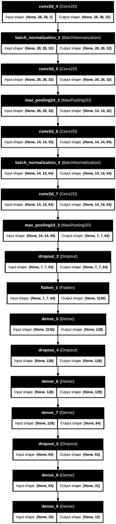

```python
from tensorflow.keras.utils import plot_model

# Guardar la imagen del modelo
plot_model(model6, to_file='model6_architecture.png', show_shapes=True, show_layer_names=True)

# Mostrar la imagen en el cuaderno
from IPython.display import Image
Image(filename='model6_architecture.png')
```

Ahora bien, *Batch Normalization* se implementó como técnica para intentar estabilizar el modelo. Ésta tecnica (como su nombre lo dice) normaliza las entradas a las capas dentro de la red calculando la media y la varianza de un batch de entradas, para luego recentrarlas y reescalarlas para que tengan una media cero y una varianza unitaria. Esto con la finalidad de estabilizar al modelo.

```python
#Optimizador
opt=tf.keras.optimizers.Adam(learning_rate=0.001)

# Funcion de paro
from tensorflow.keras.callbacks import EarlyStopping
early_stop=EarlyStopping(monitor='val_accuracy',patience=10,restore_best_weights=True)

from tensorflow.keras.callbacks import ReduceLROnPlateau

reduce_lr = ReduceLROnPlateau(
    monitor='val_loss',
    factor=0.5,
    patience=5,
    min_lr=1e-6,
    verbose=1
)

model6.compile(optimizer=opt,loss='categorical_crossentropy',metrics=['accuracy'])

model6.summary()
```

```
Model: "sequential_1"
```

```
┏━━━━━━━━━━━━━━━━━━━━━━━━━━━━━━━━━┳━━━━━━━━━━━━━━━━━━━━━━━━┳━━━━━━━━━━━━━━━┓
┃ Layer (type)                    ┃ Output Shape           ┃       Param # ┃
┡━━━━━━━━━━━━━━━━━━━━━━━━━━━━━━━━━╇━━━━━━━━━━━━━━━━━━━━━━━━╇━━━━━━━━━━━━━━━┩
│ conv2d_4 (Conv2D)               │ (None, 28, 28, 32)     │           320 │
├─────────────────────────────────┼────────────────────────┼───────────────┤
│ batch_normalization_2           │ (None, 28, 28, 32)     │           128 │
│ (BatchNormalization)            │                        │               │
├─────────────────────────────────┼────────────────────────┼───────────────┤
│ conv2d_5 (Conv2D)               │ (None, 28, 28, 32)     │         9,248 │
├─────────────────────────────────┼────────────────────────┼───────────────┤
│ max_pooling2d_2 (MaxPooling2D)  │ (None, 14, 14, 32)     │             0 │
├─────────────────────────────────┼────────────────────────┼───────────────┤
│ conv2d_6 (Conv2D)               │ (None, 14, 14, 64)     │        18,496 │
├─────────────────────────────────┼────────────────────────┼───────────────┤
│ batch_normalization_3           │ (None, 14, 14, 64)     │           256 │
│ (BatchNormalization)            │                        │               │
├─────────────────────────────────┼────────────────────────┼───────────────┤
│ conv2d_7 (Conv2D)               │ (None, 14, 14, 64)     │        36,928 │
├─────────────────────────────────┼────────────────────────┼───────────────┤
│ max_pooling2d_3 (MaxPooling2D)  │ (None, 7, 7, 64)       │             0 │
├─────────────────────────────────┼────────────────────────┼───────────────┤
│ dropout_3 (Dropout)             │ (None, 7, 7, 64)       │             0 │
├─────────────────────────────────┼────────────────────────┼───────────────┤
│ flatten_1 (Flatten)             │ (None, 3136)           │             0 │
├─────────────────────────────────┼────────────────────────┼───────────────┤
│ dense_5 (Dense)                 │ (None, 128)            │       401,536 │
├─────────────────────────────────┼────────────────────────┼───────────────┤
│ dropout_4 (Dropout)             │ (None, 128)            │             0 │
├─────────────────────────────────┼────────────────────────┼───────────────┤
│ dense_6 (Dense)                 │ (None, 128)            │        16,512 │
├─────────────────────────────────┼────────────────────────┼───────────────┤
│ dense_7 (Dense)                 │ (None, 64)             │         8,256 │
├─────────────────────────────────┼────────────────────────┼───────────────┤
│ dropout_5 (Dropout)             │ (None, 64)             │             0 │
├─────────────────────────────────┼────────────────────────┼───────────────┤
│ dense_8 (Dense)                 │ (None, 32)             │         2,080 │
├─────────────────────────────────┼────────────────────────┼───────────────┤
│ dense_9 (Dense)                 │ (None, 10)             │           330 │
└─────────────────────────────────┴────────────────────────┴───────────────┘
```

```
 Total params: 494,090 (1.88 MB)
```

```
 Trainable params: 493,898 (1.88 MB)
```

```
 Non-trainable params: 192 (768.00 B)
```

Otra herramienta nueva que se utilizó en este último modelo fue la de *ReduceLROnPlateau*. Esta herramienta funciona de manera similar a un *EarlyStop*, introduciendo la "paciencia" de épocas que tendrá antes de activarse. Si la métrica de interés (*loss* o **accuracy*) se queda estancada, la herramienta "detecta" que el modelo se encuentra en una meseta (plateau), y reduce el *Learning Rate* para intentar salir del estancamiento y seguir mejorando.

```python
history_custom = model6.fit(train_generator_aug,epochs=100, validation_data=val_generator_same,callbacks=[early_stop,reduce_lr])
```

```
161/161 ━━━━━━━━━━━━━━━━━━━━ 0s 23s/step - accuracy: 0.1352 - loss: 2.3357
```

```
161/161 ━━━━━━━━━━━━━━━━━━━━ 4600s 29s/step - accuracy: 0.1356 - loss: 2.3346 - val_accuracy: 0.1840 - val_loss: 2.1960 - learning_rate: 0.0010
161/161 ━━━━━━━━━━━━━━━━━━━━ 46s 287ms/step - accuracy: 0.4406 - loss: 1.5598 - val_accuracy: 0.4354 - val_loss: 1.7642 - learning_rate: 0.0010
161/161 ━━━━━━━━━━━━━━━━━━━━ 46s 288ms/step - accuracy: 0.6396 - loss: 1.0786 - val_accuracy: 0.7627 - val_loss: 0.9158 - learning_rate: 0.0010
161/161 ━━━━━━━━━━━━━━━━━━━━ 46s 282ms/step - accuracy: 0.7322 - loss: 0.8775 - val_accuracy: 0.7596 - val_loss: 0.8164 - learning_rate: 0.0010
161/161 ━━━━━━━━━━━━━━━━━━━━ 45s 280ms/step - accuracy: 0.7507 - loss: 0.7590 - val_accuracy: 0.7565 - val_loss: 0.7535 - learning_rate: 0.0010
161/161 ━━━━━━━━━━━━━━━━━━━━ 45s 282ms/step - accuracy: 0.7716 - loss: 0.7038 - val_accuracy: 0.8168 - val_loss: 0.6225 - learning_rate: 0.0010
161/161 ━━━━━━━━━━━━━━━━━━━━ 45s 282ms/step - accuracy: 0.7973 - loss: 0.6487 - val_accuracy: 0.7807 - val_loss: 0.7154 - learning_rate: 0.0010
161/161 ━━━━━━━━━━━━━━━━━━━━ 46s 282ms/step - accuracy: 0.8280 - loss: 0.5503 - val_accuracy: 0.8637 - val_loss: 0.4828 - learning_rate: 0.0010
161/161 ━━━━━━━━━━━━━━━━━━━━ 46s 284ms/step - accuracy: 0.8299 - loss: 0.5490 - val_accuracy: 0.8520 - val_loss: 0.5113 - learning_rate: 0.0010
161/161 ━━━━━━━━━━━━━━━━━━━━ 46s 287ms/step - accuracy: 0.8278 - loss: 0.5569 - val_accuracy: 0.8536 - val_loss: 0.5312 - learning_rate: 0.0010
161/161 ━━━━━━━━━━━━━━━━━━━━ 46s 285ms/step - accuracy: 0.8547 - loss: 0.4765 - val_accuracy: 0.8536 - val_loss: 0.4700 - learning_rate: 0.0010
161/161 ━━━━━━━━━━━━━━━━━━━━ 46s 284ms/step - accuracy: 0.8463 - loss: 0.4712 - val_accuracy: 0.8543 - val_loss: 0.5170 - learning_rate: 0.0010
161/161 ━━━━━━━━━━━━━━━━━━━━ 45s 281ms/step - accuracy: 0.8599 - loss: 0.4365 - val_accuracy: 0.8481 - val_loss: 0.4994 - learning_rate: 0.0010
161/161 ━━━━━━━━━━━━━━━━━━━━ 45s 283ms/step - accuracy: 0.8700 - loss: 0.4161 - val_accuracy: 0.8700 - val_loss: 0.4439 - learning_rate: 0.0010
161/161 ━━━━━━━━━━━━━━━━━━━━ 45s 282ms/step - accuracy: 0.8756 - loss: 0.3935 - val_accuracy: 0.8825 - val_loss: 0.4631 - learning_rate: 0.0010
161/161 ━━━━━━━━━━━━━━━━━━━━ 46s 283ms/step - accuracy: 0.8681 - loss: 0.4076 - val_accuracy: 0.8763 - val_loss: 0.4742 - learning_rate: 0.0010
161/161 ━━━━━━━━━━━━━━━━━━━━ 46s 284ms/step - accuracy: 0.8677 - loss: 0.4227 - val_accuracy: 0.8473 - val_loss: 0.4944 - learning_rate: 0.0010
161/161 ━━━━━━━━━━━━━━━━━━━━ 46s 283ms/step - accuracy: 0.8747 - loss: 0.3850 - val_accuracy: 0.8426 - val_loss: 0.5407 - learning_rate: 0.0010
161/161 ━━━━━━━━━━━━━━━━━━━━ 46s 287ms/step - accuracy: 0.8859 - loss: 0.3588 - val_accuracy: 0.8763 - val_loss: 0.4352 - learning_rate: 0.0010
161/161 ━━━━━━━━━━━━━━━━━━━━ 46s 287ms/step - accuracy: 0.8847 - loss: 0.3706 - val_accuracy: 0.8653 - val_loss: 0.4271 - learning_rate: 0.0010
161/161 ━━━━━━━━━━━━━━━━━━━━ 46s 286ms/step - accuracy: 0.8975 - loss: 0.3219 - val_accuracy: 0.8387 - val_loss: 0.5277 - learning_rate: 0.0010
161/161 ━━━━━━━━━━━━━━━━━━━━ 45s 281ms/step - accuracy: 0.8898 - loss: 0.3657 - val_accuracy: 0.5286 - val_loss: 1.5149 - learning_rate: 0.0010
161/161 ━━━━━━━━━━━━━━━━━━━━ 46s 284ms/step - accuracy: 0.8901 - loss: 0.3430 - val_accuracy: 0.8121 - val_loss: 0.5987 - learning_rate: 0.0010
161/161 ━━━━━━━━━━━━━━━━━━━━ 48s 295ms/step - accuracy: 0.9007 - loss: 0.2946 - val_accuracy: 0.8896 - val_loss: 0.4015 - learning_rate: 0.0010
161/161 ━━━━━━━━━━━━━━━━━━━━ 49s 303ms/step - accuracy: 0.9000 - loss: 0.3111 - val_accuracy: 0.8974 - val_loss: 0.4040 - learning_rate: 0.0010
161/161 ━━━━━━━━━━━━━━━━━━━━ 48s 300ms/step - accuracy: 0.8962 - loss: 0.3144 - val_accuracy: 0.8653 - val_loss: 0.4338 - learning_rate: 0.0010
161/161 ━━━━━━━━━━━━━━━━━━━━ 48s 299ms/step - accuracy: 0.9032 - loss: 0.3036 - val_accuracy: 0.8966 - val_loss: 0.3894 - learning_rate: 0.0010
161/161 ━━━━━━━━━━━━━━━━━━━━ 47s 293ms/step - accuracy: 0.9062 - loss: 0.3018 - val_accuracy: 0.8825 - val_loss: 0.4512 - learning_rate: 0.0010
161/161 ━━━━━━━━━━━━━━━━━━━━ 49s 305ms/step - accuracy: 0.9104 - loss: 0.2887 - val_accuracy: 0.8316 - val_loss: 0.5950 - learning_rate: 0.0010
161/161 ━━━━━━━━━━━━━━━━━━━━ 48s 301ms/step - accuracy: 0.9151 - loss: 0.2727 - val_accuracy: 0.8951 - val_loss: 0.4072 - learning_rate: 0.0010
161/161 ━━━━━━━━━━━━━━━━━━━━ 48s 296ms/step - accuracy: 0.9230 - loss: 0.2540 - val_accuracy: 0.7056 - val_loss: 0.9861 - learning_rate: 0.0010
161/161 ━━━━━━━━━━━━━━━━━━━━ 0s 254ms/step - accuracy: 0.9137 - loss: 0.2803
Epoch 32: ReduceLROnPlateau reducing learning rate to 0.0005000000237487257.
161/161 ━━━━━━━━━━━━━━━━━━━━ 48s 296ms/step - accuracy: 0.9137 - loss: 0.2803 - val_accuracy: 0.8387 - val_loss: 0.5916 - learning_rate: 0.0010
161/161 ━━━━━━━━━━━━━━━━━━━━ 49s 303ms/step - accuracy: 0.9192 - loss: 0.2468 - val_accuracy: 0.9060 - val_loss: 0.4077 - learning_rate: 5.0000e-04
161/161 ━━━━━━━━━━━━━━━━━━━━ 48s 296ms/step - accuracy: 0.9277 - loss: 0.2261 - val_accuracy: 0.8990 - val_loss: 0.4139 - learning_rate: 5.0000e-04
161/161 ━━━━━━━━━━━━━━━━━━━━ 48s 298ms/step - accuracy: 0.9365 - loss: 0.2035 - val_accuracy: 0.9060 - val_loss: 0.3986 - learning_rate: 5.0000e-04
161/161 ━━━━━━━━━━━━━━━━━━━━ 49s 303ms/step - accuracy: 0.9373 - loss: 0.1890 - val_accuracy: 0.8849 - val_loss: 0.4876 - learning_rate: 5.0000e-04
161/161 ━━━━━━━━━━━━━━━━━━━━ 0s 253ms/step - accuracy: 0.9412 - loss: 0.1840
Epoch 37: ReduceLROnPlateau reducing learning rate to 0.0002500000118743628.
```

[output cut: 14 more lines]

```
161/161 ━━━━━━━━━━━━━━━━━━━━ 48s 295ms/step - accuracy: 0.9544 - loss: 0.1432 - val_accuracy: 0.9107 - val_loss: 0.4303 - learning_rate: 1.2500e-04
161/161 ━━━━━━━━━━━━━━━━━━━━ 48s 299ms/step - accuracy: 0.9575 - loss: 0.1358 - val_accuracy: 0.9107 - val_loss: 0.4204 - learning_rate: 6.2500e-05
161/161 ━━━━━━━━━━━━━━━━━━━━ 48s 297ms/step - accuracy: 0.9549 - loss: 0.1377 - val_accuracy: 0.9092 - val_loss: 0.4192 - learning_rate: 6.2500e-05
161/161 ━━━━━━━━━━━━━━━━━━━━ 46s 284ms/step - accuracy: 0.9574 - loss: 0.1244 - val_accuracy: 0.9076 - val_loss: 0.4228 - learning_rate: 6.2500e-05
161/161 ━━━━━━━━━━━━━━━━━━━━ 45s 282ms/step - accuracy: 0.9516 - loss: 0.1494 - val_accuracy: 0.9068 - val_loss: 0.4201 - learning_rate: 6.2500e-05
161/161 ━━━━━━━━━━━━━━━━━━━━ 0s 241ms/step - accuracy: 0.9538 - loss: 0.1346
Epoch 52: ReduceLROnPlateau reducing learning rate to 3.125000148429535e-05.
161/161 ━━━━━━━━━━━━━━━━━━━━ 45s 280ms/step - accuracy: 0.9538 - loss: 0.1347 - val_accuracy: 0.9099 - val_loss: 0.4236 - learning_rate: 6.2500e-05
161/161 ━━━━━━━━━━━━━━━━━━━━ 45s 278ms/step - accuracy: 0.9475 - loss: 0.1530 - val_accuracy: 0.9099 - val_loss: 0.4204 - learning_rate: 3.1250e-05
161/161 ━━━━━━━━━━━━━━━━━━━━ 45s 280ms/step - accuracy: 0.9560 - loss: 0.1436 - val_accuracy: 0.9092 - val_loss: 0.4213 - learning_rate: 3.1250e-05
161/161 ━━━━━━━━━━━━━━━━━━━━ 46s 288ms/step - accuracy: 0.9549 - loss: 0.1427 - val_accuracy: 0.9045 - val_loss: 0.4213 - learning_rate: 3.1250e-05
161/161 ━━━━━━━━━━━━━━━━━━━━ 45s 283ms/step - accuracy: 0.9606 - loss: 0.1298 - val_accuracy: 0.9052 - val_loss: 0.4246 - learning_rate: 3.1250e-05
161/161 ━━━━━━━━━━━━━━━━━━━━ 0s 255ms/step - accuracy: 0.9557 - loss: 0.1326
Epoch 57: ReduceLROnPlateau reducing learning rate to 1.5625000742147677e-05.
161/161 ━━━━━━━━━━━━━━━━━━━━ 48s 296ms/step - accuracy: 0.9557 - loss: 0.1326 - val_accuracy: 0.9076 - val_loss: 0.4253 - learning_rate: 3.1250e-05
```

```python
val_loss, val_acc = model6.evaluate(val_generator_same)
print("Pérdida en validación:", val_loss)
print("Accuracy en validación:", val_acc)
```

```
40/40 ━━━━━━━━━━━━━━━━━━━━ 7s 167ms/step - accuracy: 0.8965 - loss: 0.5933
Pérdida en validación: 0.43033918738365173
Accuracy en validación: 0.9107282757759094
```

```python
# Guardar el modelo

model6.save("model6.keras")
```

Utilizando la arquitectura antes mencionada, observamos que obtuvo una mejora en *accuracy* bastante significativa comparada el modelo anterior, teniendo un 0.91 en su mejor época. Y además de ello, la diferencia entre el *accuracy* en train y en validación se redujo bastante, lo cual también es una mejora muy significativa.

[output not shown]

[output not shown]

Esta es una tabla comparativa de los *accuracies* de todos los modelos creados. Vemos que, manteniendo la mayoría de las herramientas o estructura de con forme se creaba un nuevo modelo, fue aumentando el accuracy, hasta poder llegar al mejor modelo que fue *model6*. Para dicho modelo, se generará una figura que indique con gráficas, cómo evolucionó el *accuracy* a lo largo de cada época del modelo.

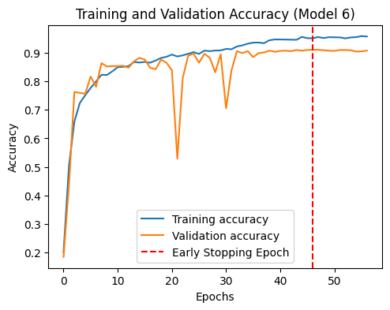

```
40/40 ━━━━━━━━━━━━━━━━━━━━ 7s 171ms/step - accuracy: 0.8965 - loss: 0.5933
Accuracy final en el conjunto de validación: 91.07%
```

```python
# --- 7. Visualización de resultados ---


plt.figure(figsize=(12,4))
plt.subplot(1,2,1)
plt.plot(history_custom.history["accuracy"], label="Training accuracy")
plt.plot(history_custom.history["val_accuracy"], label="Validation accuracy")


if 'restore_best_weights' in early_stop.__dict__ and early_stop.restore_best_weights:
    best_epoch = early_stop.stopped_epoch - early_stop.patience
    plt.axvline(x=best_epoch, color="r", linestyle="--", label="Early Stopping Epoch")

plt.title("Training and Validation Accuracy (Model 6)")
plt.xlabel("Epochs")
plt.ylabel("Accuracy")
plt.legend()
plt.show()

# --- 8. Evaluación final ---
val_loss, val_accuracy = model6.evaluate(val_generator_same)
print(f"Accuracy final en el conjunto de validación: {val_accuracy*100:.2f}%")
```

Para las gráficas generadas, observamos que el *accuracy* de entrenamiento (línea azul) comienza en un valor bajo, pero mejora rápidamente a medida que avanzan las épocas. A partir de la época 15-20, se estabiliza alrededor del 0.9, lo que indica que el modelo está aprendiendo de manera efectiva y está alcanzando buenos resultados en los datos de entrenamiento.